# Chapter 3

Tuomas Mäkelä

16 11 2019

# Doing logistic regression analysis

## 1. The data.

Just for fun and games we will print the summary of the data we are about to use. The summary is somewhat difficult to read, so feel free to skip to the actual work.

Looking at the data:

```
##        X          school   sex          age        address famsize
##  Min.   :  1.00   GP:342   F:198   Min.   :15.00   R: 81   GT3:278
##  1st Qu.: 96.25   MS: 40   M:184   1st Qu.:16.00   U:301   LE3:104
##  Median :191.50                    Median :17.00
##  Mean   :191.50                    Mean   :16.59
##  3rd Qu.:286.75                    3rd Qu.:17.00
##  Max.   :382.00                    Max.   :22.00
##  Pstatus      Medu            Fedu             Mjob           Fjob
##  A: 38   Min.   :0.000   Min.   :0.000   at_home : 53   at_home : 16
##  T:344   1st Qu.:2.000   1st Qu.:2.000   health  : 33   health  : 17
##          Median :3.000   Median :3.000   other   :138   other   :211
##          Mean   :2.806   Mean   :2.565   services: 96   services:107
##          3rd Qu.:4.000   3rd Qu.:4.000   teacher : 62   teacher : 31
##          Max.   :4.000   Max.   :4.000
##         reason    nursery   internet    guardian     traveltime
##  course    :140   no : 72   no : 58   father: 91   Min.   :1.000
##  home      :110   yes:310   yes:324   mother:275   1st Qu.:1.000
##  other     : 34                       other : 16   Median :1.000
##  reputation: 98                                    Mean   :1.448
##                                                    3rd Qu.:2.000
##                                                    Max.   :4.000
##    studytime        failures      schoolsup famsup     paid     activities
##  Min.   :1.000   Min.   :0.0000   no :331   no :144   no :205   no :181
##  1st Qu.:1.000   1st Qu.:0.0000   yes: 51   yes:238   yes:177   yes:201
##  Median :2.000   Median :0.0000
##  Mean   :2.037   Mean   :0.2016
##  3rd Qu.:2.000   3rd Qu.:0.0000
##  Max.   :4.000   Max.   :3.0000
##  higher    romantic      famrel         freetime        goout
##  no : 18   no :261   Min.   :1.000   Min.   :1.00   Min.   :1.000
##  yes:364   yes:121   1st Qu.:4.000   1st Qu.:3.00   1st Qu.:2.000
##                      Median :4.000   Median :3.00   Median :3.000
##                      Mean   :3.937   Mean   :3.22   Mean   :3.113
##                      3rd Qu.:5.000   3rd Qu.:4.00   3rd Qu.:4.000
##                      Max.   :5.000   Max.   :5.00   Max.   :5.000
##       Dalc            Walc           health         absences
##  Min.   :1.000   Min.   :1.000   Min.   :1.000   Min.   : 0.0
##  1st Qu.:1.000   1st Qu.:1.000   1st Qu.:3.000   1st Qu.: 1.0
##  Median :1.000   Median :2.000   Median :4.000   Median : 3.0
##  Mean   :1.482   Mean   :2.296   Mean   :3.573   Mean   : 4.5
##  3rd Qu.:2.000   3rd Qu.:3.000   3rd Qu.:5.000   3rd Qu.: 6.0
##  Max.   :5.000   Max.   :5.000   Max.   :5.000   Max.   :45.0
##        G1              G2              G3           alc_use
##  Min.   : 2.00   Min.   : 4.00   Min.   : 0.00   Min.   :1.000
##  1st Qu.:10.00   1st Qu.:10.00   1st Qu.:10.00   1st Qu.:1.000
##  Median :12.00   Median :12.00   Median :12.00   Median :1.500
##  Mean   :11.49   Mean   :11.47   Mean   :11.46   Mean   :1.889
##  3rd Qu.:14.00   3rd Qu.:14.00   3rd Qu.:14.00   3rd Qu.:2.500
##  Max.   :18.00   Max.   :18.00   Max.   :18.00   Max.   :5.000
##   high_use
##  Mode :logical
##  FALSE:268
##  TRUE :114
##
##
##
```

```
##  [1] "X"          "school"     "sex"        "age"        "address"
##  [6] "famsize"    "Pstatus"    "Medu"       "Fedu"       "Mjob"
## [11] "Fjob"       "reason"     "nursery"    "internet"   "guardian"
## [16] "traveltime" "studytime"  "failures"   "schoolsup"  "famsup"
## [21] "paid"       "activities" "higher"     "romantic"   "famrel"
## [26] "freetime"   "goout"      "Dalc"       "Walc"       "health"
## [31] "absences"   "G1"         "G2"         "G3"         "alc_use"
## [36] "high_use"
```

The data consists of 36 variables and 382 observations. The first column X is only the identification number for the data. The data is gathered from two schools with a questionnaire to students and school reports and wrangled so that only students who studied both mathematics and portuguese are included.

We are interested in the link between alcohol consumption (specifically binary response, high or low) and some other interesting variables. Specifically, we will look at the variables “absences”, “health”, “sex” and “G3”, which means the mean final grade of math and portuguese of the student in question.

The basic assumptions are clear: high alcohol consumption could have an increasing effect on absences, a decreasing effect on health, sex could well have an effect on consumption (either way, but mostly women tend to drink less) and finally, the final grade should sink if one consumes a lot.

## 2. Graphical and numerical analysis

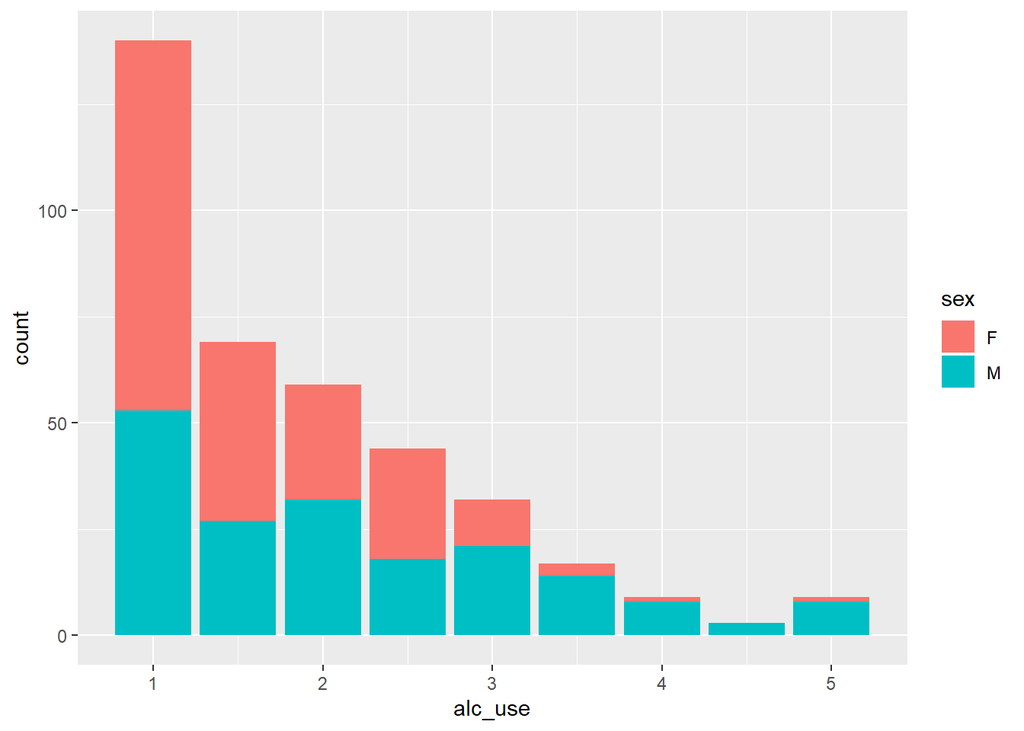

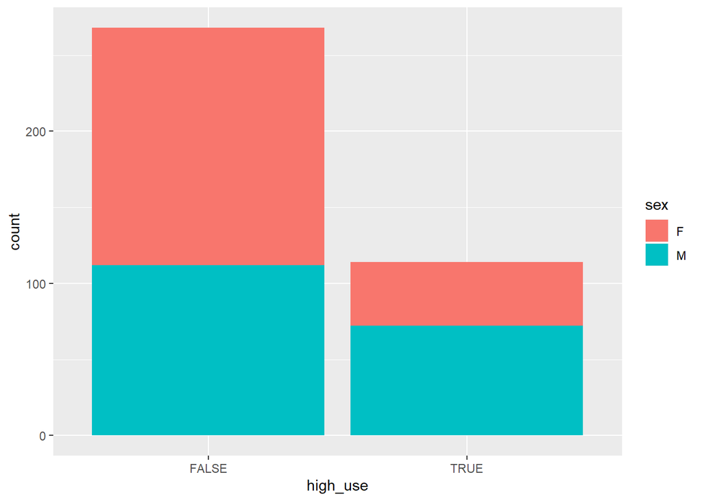

Looking at the distribution of the sex variable, we see what was assumed: women consume slightly less. Now let’s draw a more detailed plot of what’s going on in the variables.

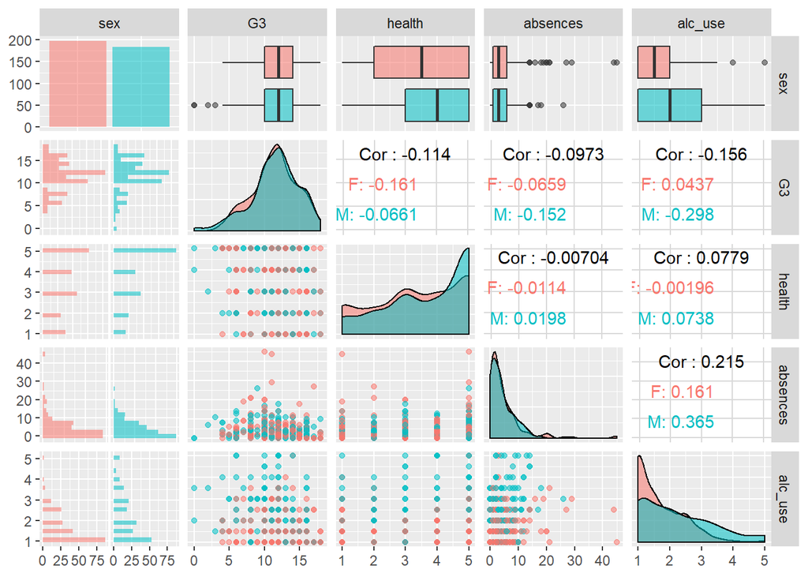

From the graphs we see that the assumptions made previously seem somewhat correct; the correlation between alc_use and G3 is negative, especially in men, while the correlation between absences and alc_use is positive. Health does not seem to have a significant relation to alc_use, probably because the effects of alcohol use do not onset until later. Interestingly, all the distributions (on the diagonal) of the variables seem to be similar fo the sexes, except for alcohol consumption, which is significantly more skewed to the left for women. This leads to the question of validity: do the students answer differently based on sex?

## 3. The logit model

We will now fit a logistic model to the data.

```
##                    OR     2.5 %    97.5 %
## (Intercept) 0.3260597 0.1046920 0.9862794
## G3          0.9284223 0.8648509 0.9957691
## absences    1.0972091 1.0509220 1.1503430
## health      1.0410775 0.8780964 1.2380464
## sexM        2.6365084 1.6462472 4.2800640
```

Here we see the summary of the fitted logistic regression model. The odds ratio for G3 is 0.9 with the confidence interval not overlapping 1 with 95% confidence. This means that odds for high G3 values mean lower odds for alcohol consumption. For absences, the odds ratio is a little over 1, wiht the confidence interval again not containing 1. This means that statistically the higher the absences, the higher the consumption of alcoho. For health we see what previously was seen; the confidence interval contains 1, which means that statistically we cannot be sure if health has any effect, and last but *not least*, the odds ratio for males compared to odds ratio of high alcohol consumption seems to be the highest in this model. This does not mean that sex is the best bet for understanding high alcohol consumption. It only states that the probability of being male seems to give some information on alcohol consumption.

Further analysis is needed if one wants to find out the best fit model for this data.

## 4. The goodness of the model

Looking at our model we decide that since health was not seemingly statistically significant, we leave it out of the model and test the predictive power of the model

$$\begin{equation*}
log(\frac{p}{1-p})=\alpha +\beta_1 x_{G3} +\beta_2 x_{Abs} +\beta_3 x_{Sex} + \epsilon
\end{equation*}$$

Where the coefficients correspond to the normal odds ratio and the odds ratios of G3, Abs and Sex, respectively.

```
##     failures absences sex high_use probability prediction
## 373        1        0   M    FALSE   0.5049363       TRUE
## 374        1        7   M     TRUE   0.6262991       TRUE
## 375        0        1   F    FALSE   0.1441082      FALSE
## 376        0        6   F    FALSE   0.2659914      FALSE
## 377        1        2   F    FALSE   0.2390368      FALSE
## 378        0        2   F    FALSE   0.1559127      FALSE
## 379        2        2   F    FALSE   0.2531066      FALSE
## 380        0        3   F    FALSE   0.2710125      FALSE
## 381        0        4   M     TRUE   0.3552815      FALSE
## 382        0        2   M     TRUE   0.3650354      FALSE
```

```
##         prediction
## high_use FALSE TRUE
##    FALSE   256   12
##    TRUE     86   28
```

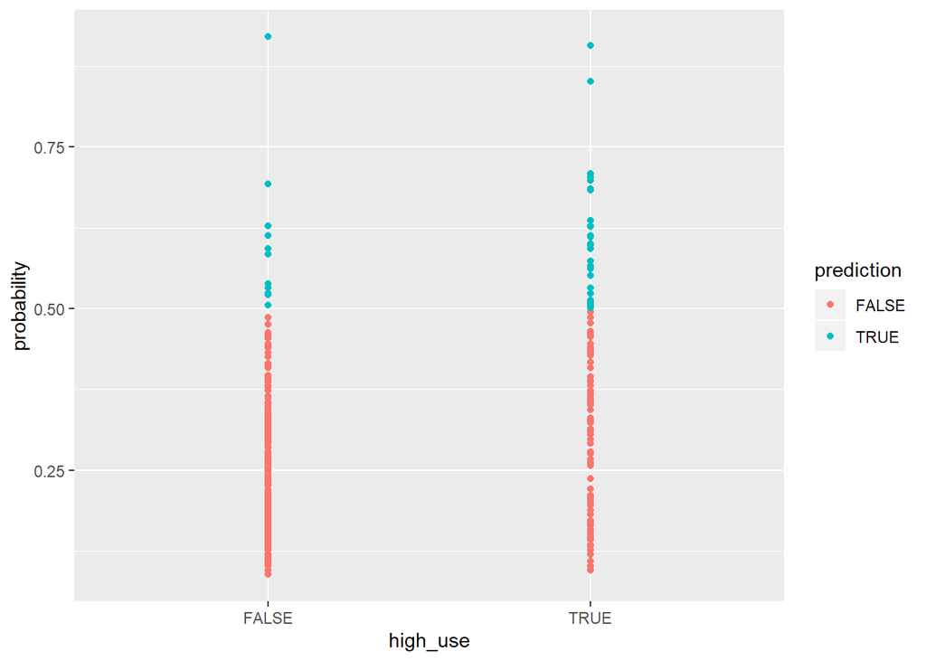